# Reproducible Research: Peer Assessment 1

Annamalai Panchanathan

Sunday, April 16, 2017

## Loading and preprocessing the data

Read in the `activity.csv` file that contains the raw data

```r
activity <- read.csv(file = "activity.csv",header = TRUE,sep = ",")
```

Print out the first 6 rows of the loaded data and the Column Names.

```
##   steps       date interval
## 1    NA 2012-10-01        0
## 2    NA 2012-10-01        5
## 3    NA 2012-10-01       10
## 4    NA 2012-10-01       15
## 5    NA 2012-10-01       20
## 6    NA 2012-10-01       25
```

```
## [1] "steps"    "date"     "interval"
```

Convert the date column from a character vector to a date

```r
activity$date <- as.Date(x = activity$date,format = "%Y-%m-%d")
```

## What is mean total number of steps taken per day?

Calculation of the total number of steps taken per day and create a histogram

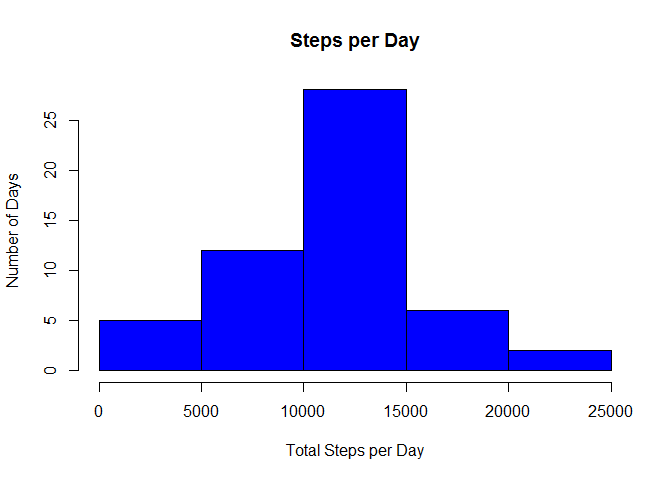

```r
steps <- aggregate(steps~date,activity,sum, na.rm = TRUE)
hist(steps$steps,main = "Steps per Day", xlab = "Total Steps per Day", ylab = "Number of Days", col = "blue")
```

Calculate the Mean and Median Values

```
## [1] "Mean total steps taken per day: 10766.188679"
```

```
## [1] "Median total steps taken per day: 10765.000000"
```

## What is the average daily activity pattern?

A time series plot (i.e. type = “l”) of the 5-minute interval (x-axis) and the average number of steps taken, averaged across all days (y-axis)

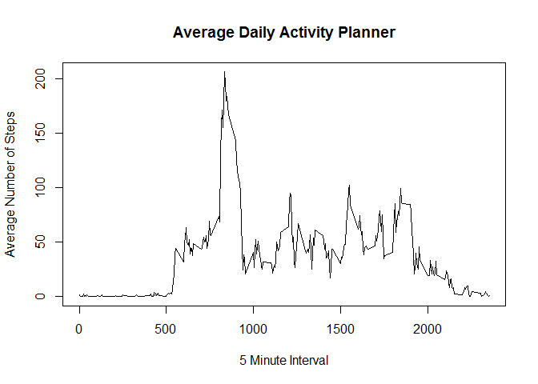

```r
avg_activity <- aggregate(steps~interval,activity,mean,na.rm = TRUE)
plot(x = avg_activity$interval,y = avg_activity$steps,type = "l",xlab = "5 Minute Interval", ylab = "Average Number of Steps",main = "Average Daily Activity Planner")
```

Which 5-minute interval, on average across all the days in the dataset, contains the maximum number of steps?

```r
max.avg_activity <- avg_activity$interval[avg_activity$steps == max(avg_activity$steps)]
print(sprintf("5-min time Interval with maximum average steps taken per day: %i",max.avg_activity))
```

```
## [1] "5-min time Interval with maximum average steps taken per day: 835"
```

## Imputing missing values

Calculate and report the total number of missing values in the dataset

```r
na.count <- sum(!complete.cases(activity))
print(sprintf("NA Count for rows with missing data: %i", na.count))
```

```
## [1] "NA Count for rows with missing data: 2304"
```

```r
new_activity <- activity
sapply(unique(activity$interval),
       function(x)
         new_activity[!complete.cases(new_activity) & (new_activity$interval == x),1] <<- avg_activity$steps[avg_activity$interval == x])
```

[output not shown]

[output cut: 43 more lines]

Calculation of the total number of steps taken per day and create a histogram

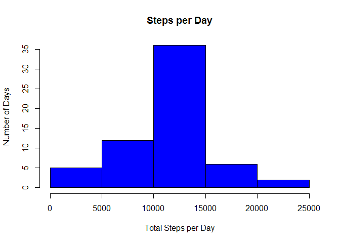

```r
news_teps <- aggregate(steps~date,new_activity,sum)
hist(news_teps$steps,main = "Steps per Day", xlab = "Total Steps per Day", ylab = "Number of Days", col = "blue")
```

Calculate the Mean and Median Values

```
## [1] "Mean total steps taken per day: 10766.188679"
```

```
## [1] "Median total steps taken per day: 10766.188679"
```

## Are there differences in activity patterns between weekdays and weekends?

```r
new_activity$weekend <- "weekday"
new_activity$weekend[weekdays(new_activity$date) %in% c("Saturday", "Sunday")] <- "weekend"
new_activity$weekend <- as.factor(new_activity$weekend)
steps_by_day <- aggregate(steps~interval + weekend,data = new_activity,FUN = mean)
```

Make a panel plot containing a time series plot (i.e. type = “l”) of the 5-minute interval (x-axis) and the average number of steps taken, averaged across all weekday days or weekend days (y-axis). See the README file in the GitHub repository to see an example of what this plot should look like using simulated data.

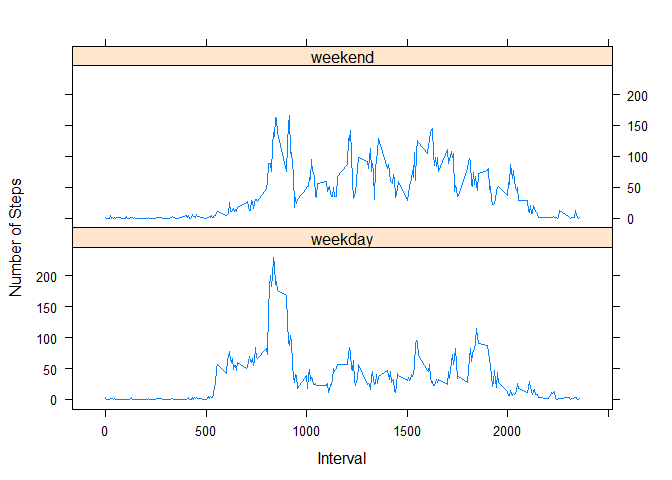